# Examining CG info

Emma Fuller

May 6, 2014

Would like to link catch profiles to vessel data in the fish ticket and coast guard databases. The coastguard data is huge (like 542338 rows). First step is to reduce the coastguard entries to vessel IDs we have in the fish ticket data.

## Subsetting CG data

```r
# reduce cg just to vessel IDs that we have in FTL
veid <- log_tripTable[[2]]$veid
veid <- unique(veid)
cg_sub <- subset(cg, vid %in% veid, select=c("vid","grosswt","netwt","len","breadth","depth"))

#remove straight duplicates
cg_sub <- cg_sub[-which(duplicated(cg_sub)),]
any(duplicated(cg_sub$vid))
```

```
## [1] TRUE
```

But there are duplicates in the coastguard data, why is that? Are there differences in the vessel measurements?

## Examining duplicates

By finding those vessels that have more than one record, look at the mean and standard deviation of these relevant vessel characteristics. If there was a standard deviation of 0, would mean that there’s no change.

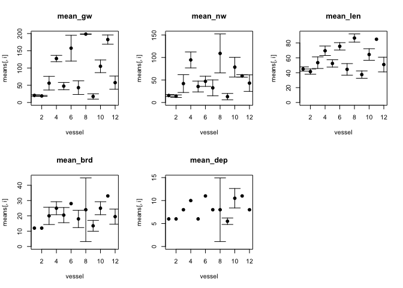

There’s quite a lot of variance in these different records. There are no vessels that don’t have a change in any of these records. Why would these vessel characteristics change? Regardless it suggests that I should drop these vessels from the metier analysis

```r
# drop vessels that have changing measurements
  var_vids <- unique(means$vid)
  # remove from cg_sub
  cg_sub <- cg_sub[which(!cg_sub$vid %in% var_vids),]
  # remove from veids
  veid <- veid[which(!veid %in% var_vids)]

# now, which vessels are missing (excluding weird vessels)?
  missing <- veid[!veid %in% cg_sub$vid]
  # check that I have a correct length
  length(veid)-length(missing) == nrow(cg_sub)
```

```
## [1] TRUE
```

There now are only about 21% of vessels are in the coastguard data that’s also in the fish ticket data. What types are captured, which ones are not?

## Examining coverage of CG

The possible metier clusters could be on catch profile, gross weight, net weight, length, breadth and depth, and gear type. The first question is whether net weight, length, breadth and depth are each useful to include.

```r
# find gear information
missing_info <- subset(log_tripTable[[2]],log_tripTable[[2]]$veid %in% missing,select=c("veid","grgroup","grid"))
missing_info <- missing_info[-which(duplicated(missing_info)),]

# still more entries from the FTL then there are vessel ids
length(missing) < nrow(missing_info)
```

```
## [1] TRUE
```

```r
# but there are the same number of different vessels
length(missing) == length(unique(missing_info$veid))
```

```
## [1] TRUE
```

```r
# which means that there are some with different gear codes. To find that, find the vessels that are duplicated

dup_gears <- missing_info[which((duplicated(missing_info$veid) | duplicated(missing_info$veid, fromLast = TRUE))),]
dup_gears <- dup_gears[order(dup_gears$veid),]
```

Ah, but actually the gear shifting is okay, I might expect that to happen, this was the whole point, after all, to look at metiers. So it won’t be perfect, but I’ll just take the first record of `grgroup` because that seems slightly more general.

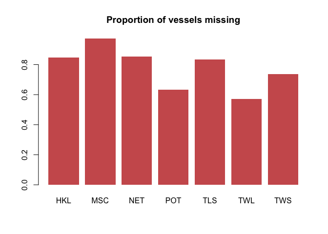

This doesn’t look like it tells me too much, it doesn’t look like a particular gear is well represented.